# Graduate Admissions Project

```r
str(Admission_Predict)
```

```
Classes spec_tbl_df, tbl_df, tbl and 'data.frame':    400 obs. of  9 variables:
 $ Serial No.       : num  1 2 3 4 5 6 7 8 9 10 ...
 $ GRE Score        : num  337 324 316 322 314 330 321 308 302 323 ...
 $ TOEFL Score      : num  118 107 104 110 103 115 109 101 102 108 ...
 $ University Rating: num  4 4 3 3 2 5 3 2 1 3 ...
 $ SOP              : num  4.5 4 3 3.5 2 4.5 3 3 2 3.5 ...
 $ LOR              : num  4.5 4.5 3.5 2.5 3 3 4 4 1.5 3 ...
 $ CGPA             : num  9.65 8.87 8 8.67 8.21 9.34 8.2 7.9 8 8.6 ...
 $ Research         : num  1 1 1 1 0 1 1 0 0 0 ...
 $ Chance of Admit  : num  0.92 0.76 0.72 0.8 0.65 0.9 0.75 0.68 0.5 0.45 ...
 - attr(*, "spec")=
  .. cols(
  ..   `Serial No.` = col_double(),
  ..   `GRE Score` = col_double(),
  ..   `TOEFL Score` = col_double(),
  ..   `University Rating` = col_double(),
  ..   SOP = col_double(),
  ..   LOR = col_double(),
  ..   CGPA = col_double(),
  ..   Research = col_double(),
  ..   `Chance of Admit` = col_double()
  .. )
```

```r
summary(Admission_Predict)
```

```
   Serial No.      GRE Score      TOEFL Score    University Rating      SOP           LOR
 Min.   :  1.0   Min.   :290.0   Min.   : 92.0   Min.   :1.000     Min.   :1.0   Min.   :1.000
 1st Qu.:100.8   1st Qu.:308.0   1st Qu.:103.0   1st Qu.:2.000     1st Qu.:2.5   1st Qu.:3.000
 Median :200.5   Median :317.0   Median :107.0   Median :3.000     Median :3.5   Median :3.500
 Mean   :200.5   Mean   :316.8   Mean   :107.4   Mean   :3.087     Mean   :3.4   Mean   :3.453
 3rd Qu.:300.2   3rd Qu.:325.0   3rd Qu.:112.0   3rd Qu.:4.000     3rd Qu.:4.0   3rd Qu.:4.000
 Max.   :400.0   Max.   :340.0   Max.   :120.0   Max.   :5.000     Max.   :5.0   Max.   :5.000
      CGPA          Research      Chance of Admit
 Min.   :6.800   Min.   :0.0000   Min.   :0.3400
 1st Qu.:8.170   1st Qu.:0.0000   1st Qu.:0.6400
 Median :8.610   Median :1.0000   Median :0.7300
 Mean   :8.599   Mean   :0.5475   Mean   :0.7244
 3rd Qu.:9.062   3rd Qu.:1.0000   3rd Qu.:0.8300
 Max.   :9.920   Max.   :1.0000   Max.   :0.9700
```

There are total of 400 observations of 9 variables.

```r
complete.cases(Admission_Predict)
```

[output not shown]

```r
Admission_Predict$`Serial No.`<- NULL
Admission_Predict$Research<-factor(Admission_Predict$Research)
str(Admission_Predict)
```

```
Classes spec_tbl_df, tbl_df, tbl and 'data.frame':    400 obs. of  8 variables:
 $ GRE Score        : num  337 324 316 322 314 330 321 308 302 323 ...
 $ TOEFL Score      : num  118 107 104 110 103 115 109 101 102 108 ...
 $ University Rating: num  4 4 3 3 2 5 3 2 1 3 ...
 $ SOP              : num  4.5 4 3 3.5 2 4.5 3 3 2 3.5 ...
 $ LOR              : num  4.5 4.5 3.5 2.5 3 3 4 4 1.5 3 ...
 $ CGPA             : num  9.65 8.87 8 8.67 8.21 9.34 8.2 7.9 8 8.6 ...
 $ Research         : Factor w/ 2 levels "0","1": 2 2 2 2 1 2 2 1 1 1 ...
 $ Chance of Admit  : num  0.92 0.76 0.72 0.8 0.65 0.9 0.75 0.68 0.5 0.45 ...
 - attr(*, "spec")=
  .. cols(
  ..   `Serial No.` = col_double(),
  ..   `GRE Score` = col_double(),
  ..   `TOEFL Score` = col_double(),
  ..   `University Rating` = col_double(),
  ..   SOP = col_double(),
  ..   LOR = col_double(),
  ..   CGPA = col_double(),
  ..   Research = col_double(),
  ..   `Chance of Admit` = col_double()
  .. )
```

I have dropped Serial No. variable as it is not a useful predictor. There are no missing values in the dataset.There are 7 numerical values and 1 categorical.

```r
attach(Admission_Predict)
numeric_attributes <- Admission_Predict[,c("GRE Score","TOEFL Score","University Rating","SOP","LOR","CGPA","Chance of Admit")]
cor(numeric_attributes)
```

```
                  GRE Score TOEFL Score University Rating       SOP       LOR      CGPA Chance of Admit
GRE Score         1.0000000   0.8359768         0.6689759 0.6128307 0.5575545 0.8330605       0.8026105
TOEFL Score       0.8359768   1.0000000         0.6955898 0.6579805 0.5677209 0.8284174       0.7915940
University Rating 0.6689759   0.6955898         1.0000000 0.7345228 0.6601235 0.7464787       0.7112503
SOP               0.6128307   0.6579805         0.7345228 1.0000000 0.7295925 0.7181440       0.6757319
LOR               0.5575545   0.5677209         0.6601235 0.7295925 1.0000000 0.6702113       0.6698888
CGPA              0.8330605   0.8284174         0.7464787 0.7181440 0.6702113 1.0000000       0.8732891
Chance of Admit   0.8026105   0.7915940         0.7112503 0.6757319 0.6698888 0.8732891       1.0000000
```

Chance of Admit has the highest corelation with CGPA as correlation coefficient between them is 0.87 and also correlation coefficient with GRE Score is 0.80.After those two , it has fair correlation with TOEFL Score as correlation coefficient between them is 0.79.

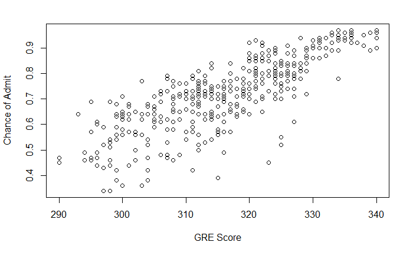

```r
attach(Admission_Predict)
plot(x = `GRE Score`, y = `Chance of Admit`)
```

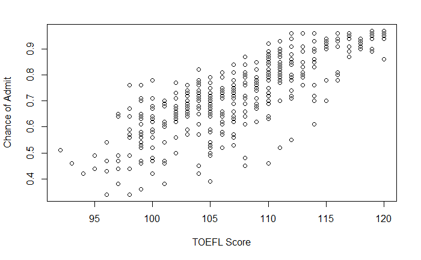

```r
plot(x = `TOEFL Score`, y = `Chance of Admit`)
```

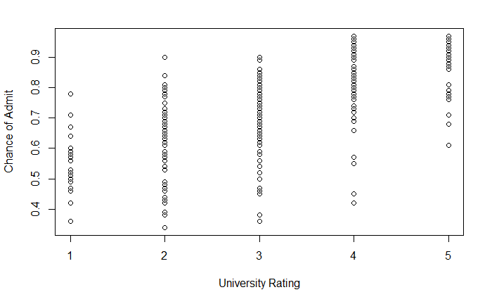

```r
plot(x = `University Rating`, y = `Chance of Admit`)
```

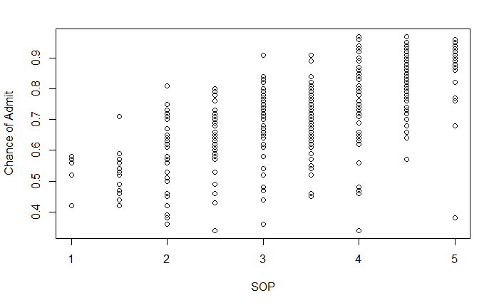

```r
plot(x = SOP, y = `Chance of Admit`)
```

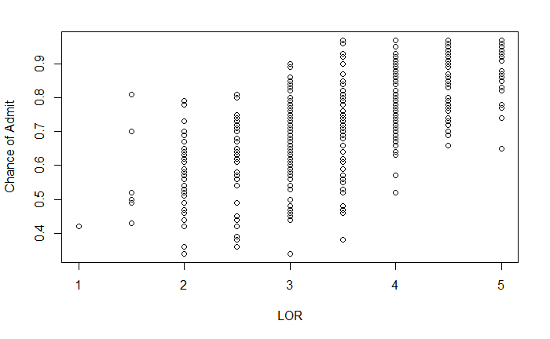

```r
plot(x = LOR, y = `Chance of Admit`)
```

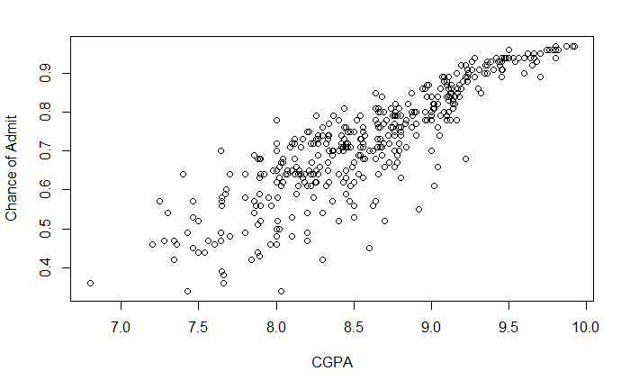

```r
plot(x = CGPA, y = `Chance of Admit`)
```

Also, to confirm the correlation, we used scatterplot and we can see that linear dependency is there between Chance of Admit and CGPA,Chance of Admit and Toefl Score. Chance of Admit and GRE Score also has linear dependency.

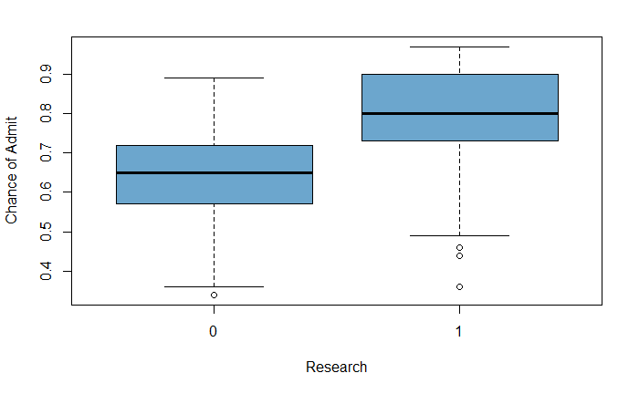

```r
plot(`Chance of Admit`~Research, col="skyblue3")
```

```r
t.test(`Chance of Admit`~Research)
```

```
    Welch Two Sample t-test

data:  Chance of Admit by Research
t = -13.347, df = 392.98, p-value < 2.2e-16
alternative hypothesis: true difference in means is not equal to 0
95 percent confidence interval:
 -0.1816199 -0.1349844
sample estimates:
mean in group 0 mean in group 1
      0.6376796       0.7959817
```

I did Side by side plot and t-test to find relation between categorical and numerical value.By doing Side by side plot test we see there is difference in the mean of Chance of Admit by Research. To confirm we did t-test and as p value is less than the significant value. We can say there is a relation between Chance of Admit and Research.

The random seed is set:

```r
set.seed(1)
```

The dataset is partitioned into test and train data:

```r
library(caret)
train.index=createDataPartition(Admission_Predict$`Chance of Admit`,p = 0.9, list = FALSE)
Admission_Predict_train=Admission_Predict[train.index , ]
Admission_Predict_test <-Admission_Predict[-train.index , ]
str(Admission_Predict_train)
```

```
Classes tbl_df, tbl and 'data.frame':   362 obs. of  8 variables:
 $ GRE Score        : num  324 322 314 330 321 308 323 327 328 307 ...
 $ TOEFL Score      : num  107 110 103 115 109 101 108 111 112 109 ...
 $ University Rating: num  4 3 2 5 3 2 3 4 4 3 ...
 $ SOP              : num  4 3.5 2 4.5 3 3 3.5 4 4 4 ...
 $ LOR              : num  4.5 2.5 3 3 4 4 3 4.5 4.5 3 ...
 $ CGPA             : num  8.87 8.67 8.21 9.34 8.2 7.9 8.6 9 9.1 8 ...
 $ Research         : Factor w/ 2 levels "0","1": 2 2 1 2 2 1 1 2 2 2 ...
 $ Chance of Admit  : num  0.76 0.8 0.65 0.9 0.75 0.68 0.45 0.84 0.78 0.62 ...
```

```r
str(Admission_Predict_test)
```

```
Classes tbl_df, tbl and 'data.frame':   38 obs. of  8 variables:
 $ GRE Score        : num  337 316 302 325 319 295 300 331 340 320 ...
 $ TOEFL Score      : num  118 104 102 106 106 93 97 112 120 110 ...
 $ University Rating: num  4 3 1 3 3 1 2 5 4 5 ...
 $ SOP              : num  4.5 3 2 3.5 4 2 3 4 5 5 ...
 $ LOR              : num  4.5 3.5 1.5 4 3 2 3 5 5 4.5 ...
 $ CGPA             : num  9.65 8 8 8.4 8 7.2 8.1 9.8 9.5 9.22 ...
 $ Research         : Factor w/ 2 levels "0","1": 2 2 1 2 2 1 2 2 2 2 ...
 $ Chance of Admit  : num  0.92 0.72 0.5 0.52 0.65 0.46 0.65 0.94 0.96 0.92 ...
```

Predicting Chance of Admit Using Regularized Linear Regression:

The random seed is set again:

```r
set.seed(1)
```

A Lasso Linear Regression model is trained using 10-fold cross-validation and the lambda parameter is tuned using a sequence of 100 values between 0.1 and 100:

```r
lasso <- train(`Chance of Admit`~., data = Admission_Predict_train, method = "glmnet",trControl = trainControl("cv", number = 10),tuneGrid = expand.grid(alpha = 1, lambda = c(0,10^seq(-1, 2, length = 100))))
```

```
There were missing values in resampled performance measures.
```

The coefficients of the best tuned model are shown below. The beta coefficients of SOP was shrunk to zero. This means that the variable is not used to predict Chance of Admit because it is irrelevant or highly correlated with other predictors.

```r
coef(lasso$finalModel, lasso$bestTune$lambda)
```

```
8 x 1 sparse Matrix of class "dgCMatrix"
                               1
(Intercept)         -1.233104963
`GRE Score`          0.001795644
`TOEFL Score`        0.002350803
`University Rating`  0.005287281
SOP                  .
LOR                  0.020667160
CGPA                 0.120518457
Research1            0.022916954
```

The model is used to make predictions on the test data and the RMSE is computed:

```r
predictions <- predict(lasso, Admission_Predict_test)
lasso.rmse <- RMSE(predictions, Admission_Predict_test$`Chance of Admit`)
lasso.rmse
```

```
[1] 0.06517812
```

A Ridge Regression Model is trained using 10-fold cross-validation and the lambda parameter is tuned using a sequence of 100 values between 0.1 and 100:

```r
set.seed(1)
ridge <- train(`Chance of Admit`~., data = Admission_Predict_train, method = "glmnet",trControl = trainControl("cv", number = 10),tuneGrid = expand.grid(alpha = 0, lambda = 10^seq(-1, 2, length = 100)))
predictions <- predict(ridge,Admission_Predict_test)
ridge.rmse <-RMSE(predictions, Admission_Predict_test$`Chance of Admit`)
ridge.rmse
```

```
[1] 0.07056521
```

An Elastic Net Linear Regression Model is trained using 10-fold cross-validation. The alpha parameter is tuned using a sequence of 10 values between 0 and 1. The lambda parameter is tuned using a sequence of 100 values between 0.1 and 100:

```r
set.seed(1)
enet <- train(
  `Chance of Admit` ~., data = Admission_Predict_train, method = "glmnet",
  trControl = trainControl("cv", number = 10),
  tuneGrid = expand.grid(alpha =seq(0,1, length=10), lambda = 10^seq(-1, 2, length = 100)))
```

```
There were missing values in resampled performance measures.
```

```r
predictions <- predict(enet,Admission_Predict_test)
enet.rmse <- RMSE(predictions, Admission_Predict_test$`Chance of Admit`)
enet.rmse
```

```
[1] 0.07056521
```

Predicting Chance of Admit Using Artificial Neural Networks The Admission_Predict_train dataset is split into 90% training and 10% validation sets:

```r
set.seed(1)
train.index <- createDataPartition(Admission_Predict_train$`Chance of Admit`, p = 0.9, list = FALSE)
Admission_Predict_train_nn <- Admission_Predict_train[train.index, ]
Admission_Predict_validation_nn <- Admission_Predict_train[-train.index, ]
```

To scale the attributes selectively, the scaled attributes and non-scaled attributes are stored in separate objects then combined using the cbind() function. This process is repeated for the test and validation sets using the normalization parameters from the training set:

```r
train.not.scaled <- Admission_Predict_train_nn [ , c(7,8)]
Admission_Predict_train_nn  <- scale(Admission_Predict_train_nn [ , c(-7,-8)])
col.means.train <- attr(Admission_Predict_train_nn , "scaled:center")
col.stddevs.train <- attr(Admission_Predict_train_nn , "scaled:scale")
#Note: the column order is changed after appending the non-scaled attributes
Admission_Predict_train_nn  <- cbind(Admission_Predict_train_nn , train.not.scaled)
val.not.scaled <- Admission_Predict_validation_nn [ , c(7,8)]
Admission_Predict_validation_nn <- scale(Admission_Predict_validation_nn[ , c(-7,-8)], center = col.means.train, scale = col.stddevs.train)
Admission_Predict_validation_nn <- cbind(Admission_Predict_validation_nn, val.not.scaled)
test.not.scaled <- Admission_Predict_test[ , c(7,8)]
Admission_Predict_test<- scale(Admission_Predict_test[ , c(-7,-8)], center = col.means.train, scale = col.stddevs.train)
Admission_Predict_test<- cbind(Admission_Predict_test, test.not.scaled)
str(Admission_Predict_train_nn)
```

```
'data.frame':   327 obs. of  8 variables:
 $ GRE Score        : num  0.441 -0.249 0.354 -0.766 0.527 ...
 $ TOEFL Score      : num  0.4001 -0.7665 0.2334 -1.0998 0.0668 ...
 $ University Rating: num  -0.0807 -0.9604 -0.0807 -0.9604 -0.0807 ...
 $ SOP              : num  0.105 -1.39 -0.393 -0.393 0.105 ...
 $ LOR              : num  -1.087 -0.529 0.587 0.587 -0.529 ...
 $ CGPA             : num  0.11448 -0.66122 -0.67809 -1.18399 -0.00356 ...
 $ Research         : Factor w/ 2 levels "0","1": 2 1 2 1 1 2 2 2 2 1 ...
 $ Chance of Admit  : num  0.8 0.65 0.75 0.68 0.45 0.84 0.78 0.62 0.61 0.54 ...
```

```r
library(keras)
set.seed(1)
Admission_Predict_train_nn_labels <- as.matrix(Admission_Predict_train_nn[8])
Admission_Predict_train_nn <- as.matrix(Admission_Predict_train_nn[-8])
Admission_Predict_validation_nn_labels <- as.matrix(Admission_Predict_validation_nn[8])
Admission_Predict_validation_nn <- as.matrix(Admission_Predict_validation_nn[-8])
```

An initial neural network is fitted using one hidden layer with 15 neurons, a drop out factor of .5, a mini-batch size of 50, and the Adam optimizer algorithm.

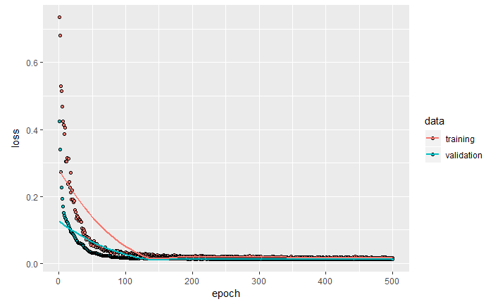

```r
set.seed(1)
model1 <- keras_model_sequential() %>%
  layer_dense(units = 15, activation = "relu", input_shape = dim(Admission_Predict_train_nn)[2]) %>%
  layer_dropout(0.5) %>%
  layer_dense(units = 1)
#The assignment specifies the SGD optimizer, but Adam is used instead
#The output variable is not scaled, so the SGD algorithm results in the exploding gradient problem
model1 %>% compile(loss = "mse", optimizer = "adam")
history <- model1 %>% fit(Admission_Predict_train_nn, log(Admission_Predict_train_nn_labels),
                         batch_size = 50, epochs = 500,
                         verbose = 0,
                         validation_data = list(Admission_Predict_validation_nn, log(Admission_Predict_validation_nn_labels)))
plot(history)
```

```r
predictions <- model1 %>% predict(Admission_Predict_validation_nn)
RMSE(exp(predictions), Admission_Predict_validation_nn_labels)
```

```
[1] 0.06393291
```

The number of neurons in the hidden layer and the mini-batch sizes are tuned to increase model performance. First, we’ll increase the number of neurons from 15 to 20 and keep the batch size unchanged:

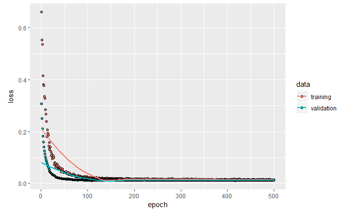

```r
set.seed(1)
model2 <- keras_model_sequential() %>%
  layer_dense(units = 20, activation = "relu", input_shape = dim(Admission_Predict_train_nn)[2]) %>%
  layer_dropout(0.5) %>%
  layer_dense(units = 1)
model2 %>% compile(loss = "mse", optimizer = "adam")
set.seed(1)
history <- model2 %>% fit(Admission_Predict_train_nn, log(Admission_Predict_train_nn_labels),
                         batch_size = 50, epochs = 500,
                         verbose = 0,
                         validation_data = list(Admission_Predict_validation_nn, log(Admission_Predict_validation_nn_labels)))
plot(history)
```

```r
predictions <- model2 %>% predict(Admission_Predict_validation_nn)
RMSE(exp(predictions), Admission_Predict_validation_nn_labels)
```

```
[1] 0.06595817
```

This model3 increases the number of neurons to 50 and uses the same mini-batch size as above:

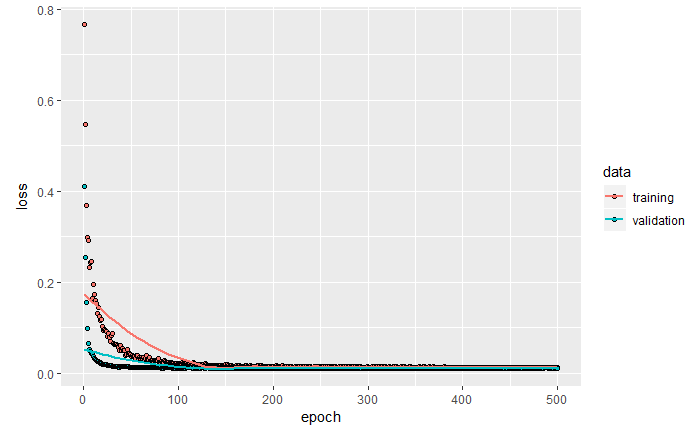

```r
set.seed(1)
model3 <- keras_model_sequential() %>%
  layer_dense(units = 50, activation = "relu", input_shape = dim(Admission_Predict_train_nn)[2]) %>%
  layer_dropout(0.5) %>%
  layer_dense(units = 1)
model3 %>% compile(loss = "mse", optimizer = "adam")
set.seed(1)
history <- model3 %>% fit(Admission_Predict_train_nn, log(Admission_Predict_train_nn_labels),
                         batch_size = 50, epochs = 500,
                         verbose = 0,
                         validation_data = list(Admission_Predict_validation_nn, log(Admission_Predict_validation_nn_labels)))
plot(history)
```

```r
predictions <- model3 %>% predict(Admission_Predict_validation_nn)
RMSE(exp(predictions), Admission_Predict_validation_nn_labels)
```

```
[1] 0.05839776
```

This model4 uses 20 neurons and a mini-batch size of 100:

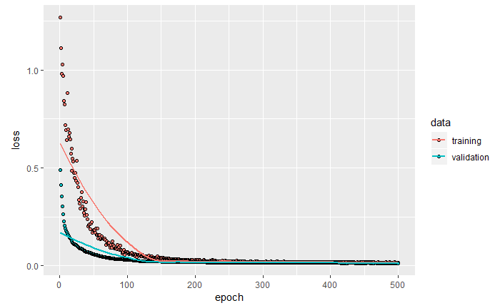

```r
set.seed(1)
model4 <- keras_model_sequential() %>%
  layer_dense(units = 20, activation = "relu", input_shape = dim(Admission_Predict_train_nn)[2]) %>%
  layer_dropout(0.5) %>%
  layer_dense(units = 1)
model4 %>% compile(loss = "mse", optimizer = "adam")
set.seed(1)
history <- model4 %>% fit(Admission_Predict_train_nn, log(Admission_Predict_train_nn_labels),
                         batch_size = 100, epochs = 500,
                         verbose = 0,
                         validation_data = list(Admission_Predict_validation_nn, log(Admission_Predict_validation_nn_labels)))
plot(history)
```

```r
predictions <- model4 %>% predict(Admission_Predict_validation_nn)
RMSE(exp(predictions), Admission_Predict_validation_nn_labels)
```

```
[1] 0.06832892
```

This model5 uses 50 neurons and a mini-batch size of 100:

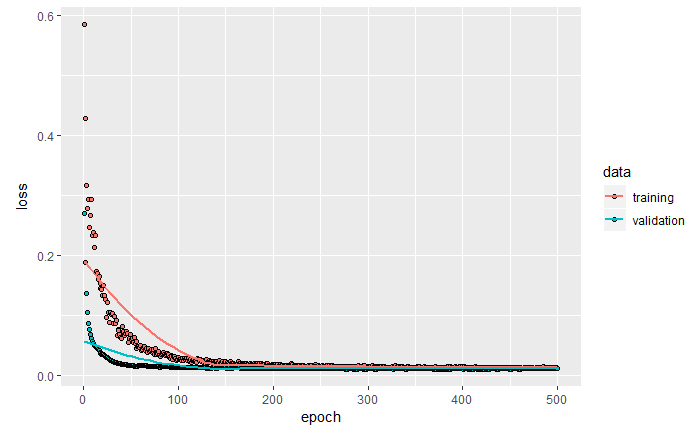

```r
set.seed(1)
model5 <- keras_model_sequential() %>%
  layer_dense(units = 50, activation = "relu", input_shape = dim(Admission_Predict_train_nn)[2]) %>%
  layer_dropout(0.5) %>%
  layer_dense(units = 1)
model5 %>% compile(loss = "mse", optimizer = "adam")
set.seed(1)
history <- model5 %>% fit(Admission_Predict_train_nn, log(Admission_Predict_train_nn_labels),
                         batch_size = 100, epochs = 500,
                         verbose = 0,
                         validation_data = list(Admission_Predict_validation_nn, log(Admission_Predict_validation_nn_labels)))
plot(history)
```

```r
predictions <- model5 %>% predict(Admission_Predict_validation_nn)
RMSE(exp(predictions), Admission_Predict_validation_nn_labels)
```

```
[1] 0.06105439
```

It seems that model3 gives the lowest RMSE than other models.

The best model from the above is used to find chance of admit values for Admission_Predict_test.

```r
Admission_Predict_test_labels <- as.matrix(Admission_Predict_test[8])
Admission_Predict_test <- as.matrix(Admission_Predict_test[-8])
predictions <- model3 %>% predict(Admission_Predict_test)
nn.rmse <- RMSE(exp(predictions), Admission_Predict_test_labels)
nn.rmse
```

```
[1] 0.07151191
```

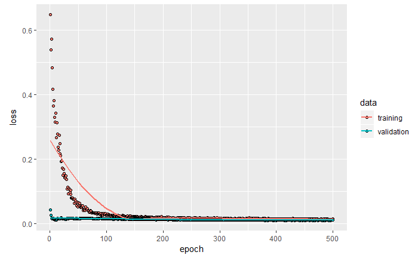

```r
set.seed(1)
model3 <- keras_model_sequential() %>%
  layer_dense(units = 50, activation = "relu", input_shape = dim(Admission_Predict_train_nn)[2]) %>%
  layer_dropout(0.5) %>%
  layer_dense(units = 50, activation = "sigmoid")%>%
  layer_dropout(0.5)%>%

  layer_dense(units = 1)
model3 %>% compile(loss = "mse", optimizer = "adam")
history <- model3 %>% fit(Admission_Predict_train_nn, log(Admission_Predict_train_nn_labels),
                         batch_size = 50, epochs = 500,
                         verbose = 0,
                         validation_data = list(Admission_Predict_validation_nn, log(Admission_Predict_validation_nn_labels)))
plot(history)
```

```r
predictions <- model4 %>% predict(Admission_Predict_test)
nn.RMSE=RMSE(exp(predictions), Admission_Predict_test_labels)
nn.RMSE
```

```
[1] 0.07228091
```

In general though, to make conclusion about the hyper-parameters of neural network, we need to run each model several times and then look at the average performance. We ran the best model several times now.

```r
set.seed(1)
runs=seq(1:100)
rmses=c()
for(i in runs)
{
  model3_repeat <- keras_model_sequential() %>%
    layer_dense(units = 50, activation = "relu", input_shape = dim(Admission_Predict_train_nn)[2]) %>%
  layer_dropout(0.5) %>%
  layer_dense(units = 50, activation = "sigmoid")%>%
  layer_dropout(0.5)%>%

  layer_dense(units = 1)
  model3_repeat %>% compile(loss = "mse", optimizer = "adam")
  history <- model3_repeat %>% fit(Admission_Predict_train_nn, log(Admission_Predict_train_nn_labels),
                         batch_size = 50, epochs = 500,
                         verbose = 0,
                         validation_data = list(Admission_Predict_validation_nn, log(Admission_Predict_validation_nn_labels)))
predictions <- model3_repeat %>% predict(Admission_Predict_test)
rmses=append(rmses, RMSE(exp(predictions),  Admission_Predict_test_labels))
}
```

[output not shown]

```r
rmses=append(rmses, RMSE(exp(predictions),  Admission_Predict_test_labels))
```

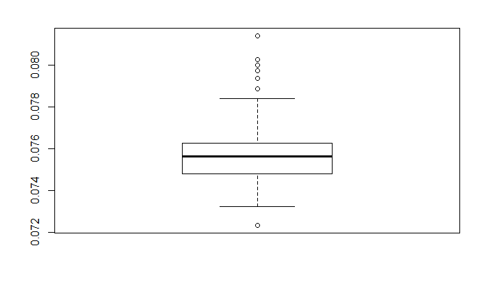

```r
boxplot(rmses)
```

```r
summary(rmses)
```

```
   Min. 1st Qu.  Median    Mean 3rd Qu.    Max.
0.07233 0.07479 0.07561 0.07578 0.07625 0.08140
```

Predicting Chance of Admit Using Random Forest and Gradient Boosted Trees:

A random forest model is created using the Caret package. First, the Admission_Predict_train and Admission_Predict_test sets are recreated to undo the changes made to the variables in the previous section:

```r
set.seed(1)
train.index=createDataPartition(Admission_Predict$`Chance of Admit`,p = 0.9, list = FALSE)
Admission_Predict_train=Admission_Predict[train.index , ]
Admission_Predict_test <-Admission_Predict[-train.index , ]
```

The model is auto-tuned using 10-fold cross-validation.

```r
set.seed(1)
m.rf <- train(`Chance of Admit` ~., data = Admission_Predict_train,
              method = "rf",
              trControl = trainControl(method = "cv", number = 10),

              importance = T)
m.rf
```

```
Random Forest

362 samples
  7 predictor

No pre-processing
Resampling: Cross-Validated (10 fold)
Summary of sample sizes: 325, 325, 327, 325, 326, 327, ...
Resampling results across tuning parameters:

  mtry  RMSE        Rsquared   MAE
  2     0.06505320  0.7898480  0.04701579
  4     0.06631229  0.7804794  0.04802502
  7     0.06809479  0.7684210  0.04904627

RMSE was used to select the optimal model using the smallest value.
The final value used for the model was mtry = 2.
```

The RMSE is calculated:

```r
predictions <- predict(m.rf, Admission_Predict_test)
rf.rmse <- RMSE(predictions, Admission_Predict_test$`Chance of Admit`)
rf.rmse
```

```
[1] 0.07007131
```

And varImp() is used to get the variable importance rankings:

```r
varImp(m.rf)
```

```
rf variable importance
```

|  | Overall |
| --- | --- |
| CGPA | 100.000000 |
| `GRE Score` | 44.416564 |
| Research1 | 17.868033 |
| `TOEFL Score` | 11.390589 |
| `University Rating` | 10.170105 |
| LOR | 2.760883 |
| SOP | 0.000000 |

A Gradient Boosted Tree is created using the Admission_Predict_train data and the RMSE is calculated:

```r
set.seed(1)
gbm <- train(`Chance of Admit` ~., data = Admission_Predict_train,
             method = "gbm",
             verbose = FALSE,
             trControl = trainControl("cv", number = 10))
predictions <- predict(gbm, Admission_Predict_test)
gbm.rmse <- RMSE(predictions, Admission_Predict_test$`Chance of Admit`)
gbm.rmse
```

```
[1] 0.06721274
```

Linear Regression:

From the linear regression model, we can say that variables CGPA and LOR have very statistically significant effect on the outcome as their p value is between 0 and 0.001.

```r
library(caret)
train.control =trainControl(method = "cv", number = 10)
set.seed(1)
model =train(`Chance of Admit`~.,data = Admission_Predict_train,method = "lm",trControl = train.control)
print(model)
```

```
Linear Regression

362 samples
  7 predictor

No pre-processing
Resampling: Cross-Validated (10 fold)
Summary of sample sizes: 325, 325, 327, 325, 326, 327, ...
Resampling results:

  RMSE        Rsquared   MAE
  0.06344847  0.7970136  0.04605844

Tuning parameter 'intercept' was held constant at a value of TRUE
```

```r
summary(model)
```

```
Call:
lm(formula = .outcome ~ ., data = dat)

Residuals:
     Min       1Q   Median       3Q      Max
-0.26379 -0.02245  0.01022  0.03608  0.15865

Coefficients:
                           Estimate Std. Error t value Pr(>|t|)
(Intercept)               -1.243422   0.132008  -9.419  < 2e-16 ***
`\\`GRE Score\\``          0.001787   0.000624   2.864 0.004433 **
`\\`TOEFL Score\\``        0.002440   0.001125   2.169 0.030760 *
`\\`University Rating\\``  0.005966   0.004916   1.213 0.225754
SOP                       -0.001982   0.005751  -0.345 0.730619
LOR                        0.021850   0.005739   3.807 0.000166 ***
CGPA                       0.120930   0.012833   9.424  < 2e-16 ***
Research1                  0.023823   0.008357   2.851 0.004619 **
---
Signif. codes:  0 *** 0.001 ** 0.01 * 0.05 . 0.1   1

Residual standard error: 0.06368 on 354 degrees of freedom
Multiple R-squared:  0.8006,    Adjusted R-squared:  0.7967
F-statistic:   203 on 7 and 354 DF,  p-value: < 2.2e-16
```

```r
predictions <- predict(model, Admission_Predict_test)
lr.rmse <- RMSE(predictions, Admission_Predict_test$`Chance of Admit`)
lr.rmse
```

```
[1] 0.06497345
```

All the models are compared using resamples(). The summary statistics of the performance of tuned lasso, tuned ridge, tuned enet, tuned rf, tuned gbm and tuned linear regression across 10 folds are compared below.

```r
compare=resamples(list(L=lasso,R=ridge,E=enet,RF=m.rf,G=gbm,LR=model))
summary(compare)
```

```
Call:
summary.resamples(object = compare)

Models: L, R, E, RF, G, LR
Number of resamples: 10

MAE
         Min.    1st Qu.     Median       Mean    3rd Qu.       Max. NA's
L  0.03236388 0.04369070 0.04522799 0.04597964 0.05015462 0.05626655    0
R  0.04063627 0.04554356 0.05086051 0.04943335 0.05338244 0.05742906    0
E  0.04063627 0.04554356 0.05086051 0.04943335 0.05338244 0.05742906    0
RF 0.03678497 0.04504175 0.04734278 0.04701579 0.05009922 0.05405172    0
G  0.03518413 0.04550091 0.04780267 0.04776030 0.05075082 0.05829829    0
LR 0.03232238 0.04367081 0.04539900 0.04605844 0.05037574 0.05626523    0

RMSE
         Min.    1st Qu.     Median       Mean    3rd Qu.       Max. NA's
L  0.04174099 0.05845083 0.06397825 0.06336428 0.07203883 0.07503867    0
R  0.04843849 0.06138249 0.06952456 0.06755757 0.07268680 0.08037119    0
E  0.04843849 0.06138249 0.06952456 0.06755757 0.07268680 0.08037119    0
RF 0.04737921 0.06327525 0.06892781 0.06505320 0.07029598 0.07073750    0
G  0.04653415 0.06346101 0.06642888 0.06589791 0.07177888 0.08131939    0
LR 0.04178179 0.05875300 0.06384613 0.06344847 0.07202710 0.07508969    0

Rsquared
        Min.   1st Qu.    Median      Mean   3rd Qu.      Max. NA's
L  0.6866038 0.7840596 0.8095110 0.7976470 0.8338251 0.8883798    0
R  0.7164219 0.7552235 0.7907375 0.7860081 0.8111622 0.8549721    0
E  0.7164219 0.7552235 0.7907375 0.7860081 0.8111622 0.8549721    0
RF 0.7308889 0.7640821 0.7894545 0.7898480 0.8120174 0.8582328    0
G  0.6650785 0.7703803 0.8038175 0.7828863 0.8142711 0.8616184    0
LR 0.6866363 0.7840804 0.8085245 0.7970136 0.8326733 0.8884973    0
```

From the comparison of performance from the cross validation error,looking at mean of RMSE, we can say that Ridge and Enet gave the worst cross validation error. Linear regression and Lasso gave the least cross validation error.

The RMSE of every model is shown below:

```r
Rmses <- matrix(c(lasso.rmse, ridge.rmse, enet.rmse, nn.rmse, rf.rmse, gbm.rmse,lr.rmse))
colnames(Rmses) <- "RMSE"
rownames(Rmses) <- c("Lasso", "Ridge", "Enet", "NN", "RF", "GBM","Linear Regression")
as.table(Rmses)
```

```
                        RMSE
Lasso             0.06517812
Ridge             0.07056521
Enet              0.07056521
NN                0.07151191
RF                0.07007131
GBM               0.06721274
Linear Regression 0.06497345
```

It appears that Linear regression performed the best on this data.